# XC Training Network

Lucy Paynter

2025-04-09

## Introduction

For my final project, I wanted to explore how social training connections relate to fitness changes over the course of a cross country season. This question matters because teammates often train in groups, and I was curious whether being more socially connected in training might help runners improve more. I collected data from my team’s Garmin and Strava stats — including average heart rate and pace during easy runs — and combined that with survey responses on who each athlete trained with, to build a network and analyze changes in fitness.

## Methods

I surveyed my cross country teammates, asking them to report who they trained with during the season and to provide average heart rate and pace data from their Garmin or Strava apps. The training connection data was used to build a social network, where each athlete is a node and each connection is an edge. I assigned edge weights based on how often teammates trained together: a weight of 2 means they trained together regularly, and a weight of 1 means they trained together occasionally. I also added each athlete’s fitness data (heart rate and pace during preseason, peak season, and end of season) as node attributes to explore patterns across the network.

## Data Load + Cleaning

I loaded two datasets into R: one sheet with training connections (edge list) and another with heart rate and pace data (fitness data) for each athlete. In the edge list, I renamed all athletes as Athlete A, B, C, etc., to keep the data anonymous. I filtered out any responses with missing or non-numeric fitness values (like “I was injured”) and made sure all pace and heart rate entries were in number form.

I used the Garmin/Strava data to calculate how each athlete’s fitness changed over the season. To do this, I looked at their average heart rate and pace during easy runs at two time points: peak season and end of season. If someone had a lower heart rate for the same pace by the end of the season, that meant they had improved. I used this change as a way to measure individual fitness gains across the team.

```r
#set my working directory
setwd("~/Desktop/DCS 375/GitHub/FinalProject")

#make sure necessary packages are included
library(tidyverse)
```

```r
library(igraph)
library(readxl)
```

```r
# Load spreadsheet from cleaned Excel file
edges <- read_excel("EdgeList_FitnessData.xlsx", sheet = "Training Edge List")

# I am loading the training connections
# loading the HR and pace data for each athlete

fitness <- read_excel("EdgeList_FitnessData.xlsx", sheet = "Fitness Data")

# View the data
View(edges)
View(fitness)
```

```r
# Calculate fitness change for each athlete
fitness <- fitness %>%
  mutate(
    HR_Pace_Peak = HR_Peak / Pace_Peak,   # I am calculating HR-to-pace ratio at peak
    HR_Pace_End = HR_End / Pace_End,      # I am calculating HR-to-pace ratio at end
    Fitness_Change = HR_Pace_Peak - HR_Pace_End  # I am checking how much each person improved
  )

# Building the social network graph using igraph
g <- graph_from_data_frame(d = edges, vertices = fitness, directed = FALSE)
# I am creating the network using training connections and adding fitness data to each athlete
```

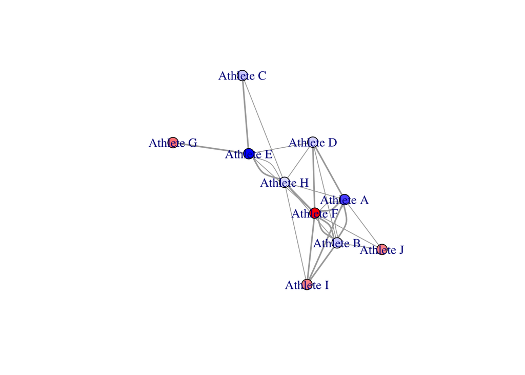

```r
# adding fitness values to a colors
colors <- colorRampPalette(c("blue", "white", "red"))(100)  # blue = less change, red = more
fitness_range <- range(V(g)$Fitness_Change, na.rm = TRUE)
color_index <- round( (V(g)$Fitness_Change - fitness_range[1]) / diff(fitness_range) * 99 ) + 1
vertex_colors <- colors[color_index]

# Plotting my network of Cross Country Training Relationships
# The node color represents fitness improvement from peak to end of season (HR/Pace) and the edge width represents training tie strength (1 = occasionally, 2 = regularly)
plot(g,
     vertex.label = V(g)$label,         # names (Athlete A, etc.)
     vertex.size = 10,
     vertex.color = vertex_colors,      # fixed color values
     edge.width = E(g)$Strength)
```

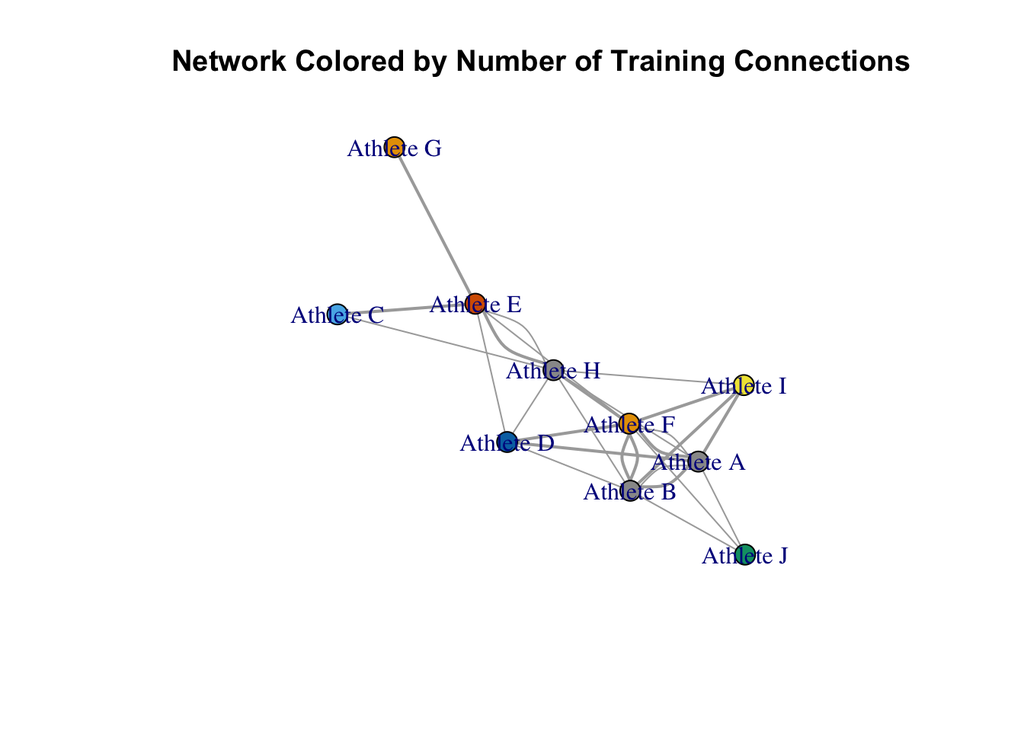

```r
#Who is the most socially connected in training?
# Color network by how connected each athlete is (degree)
fitness$Degree <- degree(g)

# Calculate how connected each athlete is
fitness$Degree <- degree(g)

# Set node color based on degree (number of training connections)
V(g)$color <- fitness$Degree

# Plot the network again with new coloring
plot(g,
     vertex.label = V(g)$label,
     vertex.size = 10,
     vertex.color = V(g)$color,
     edge.width = E(g)$Strength,
     main = "Network Colored by Number of Training Connections")
```

```r
# Calculating Fitness_Change
fitness <- fitness %>%
  mutate(
    HR_Pace_Peak = HR_Peak / Pace_Peak,
    HR_Pace_End = HR_End / Pace_End,
    Fitness_Change = HR_Pace_Peak - HR_Pace_End
  )

#Summary stats of data
summary(fitness$Fitness_Change)
```

```
##    Min. 1st Qu.  Median    Mean 3rd Qu.    Max.
## -1.9884 -0.6173 -0.5198 -0.3104  0.3602  1.3407
```

```r
mean(fitness$Fitness_Change, na.rm = TRUE)
```

```
## [1] -0.310397
```

```r
sd(fitness$Fitness_Change, na.rm = TRUE)
```

```
## [1] 0.9697829
```

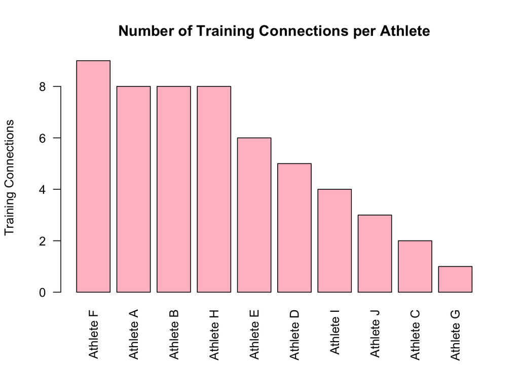

```r
# Step 1: Calculate degree (number of training connections) for each athlete and add it to fitness dataframe
fitness$Degree <- degree(g)

# Step 2: Barplot of training connections per athlete
barplot(sort(fitness$Degree, decreasing = TRUE),
        names.arg = fitness$Athlete[order(-fitness$Degree)],
        las = 2,
        col = "pink",
        main = "Number of Training Connections per Athlete",
        ylab = "Training Connections")
```

This bar plot shows how many teammates each athlete trained with during the season. A higher number means they were more connected and trained with more people. It’s based on how often others said they trained with them, either regularly or occasionally. Athletes like F, A, and B were some of the most connected, while athletes like C and G trained with fewer teammates, possibly sticking to smaller groups or doing more runs on their own. Athlete F had the most connections (9), while Athlete G had the fewest (1) and most athletes trained with 4–8 teammates.

```r
# Calculating how central each athlete is in this training network
# This looks at how connected individuals are to other well-connected teammates
fitness$Centrality <- eigen_centrality(g)$vector

# Print centrality scores to see who is most central
print(fitness[order(-fitness$Centrality), c("Athlete", "Centrality")])
```

```
## # A tibble: 10 × 2
##    Athlete   Centrality
##    <chr>          <dbl>
##  1 Athlete F     1
##  2 Athlete B     0.940
##  3 Athlete A     0.940
##  4 Athlete H     0.793
##  5 Athlete D     0.628
##  6 Athlete I     0.550
##  7 Athlete E     0.522
##  8 Athlete J     0.431
##  9 Athlete C     0.197
## 10 Athlete G     0.0781
```

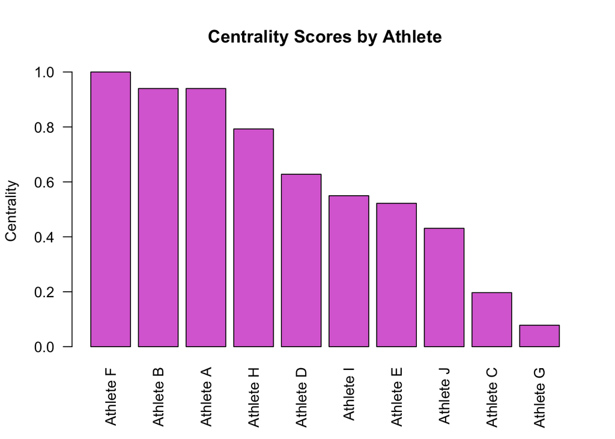

```r
# Make a barplot showing centrality scores for each athlete
barplot(sort(fitness$Centrality, decreasing = TRUE),
        names.arg = fitness$Athlete[order(-fitness$Centrality)],
        las = 2,
        col = "orchid",
        main = "Centrality Scores by Athlete",
        ylab = "Centrality")
```

This plot shows how central each athlete is in the team’s training network. Athletes like Athlete F and Athlete B had the highest centrality, meaning they trained with teammates who were also highly connected. This puts them at the core of the group’s training web. On the other end, athletes like Athlete G and Athlete C were more on the edges — they had fewer connections to teammates who were themselves well-connected. Centrality helps highlight who might’ve been at the social or motivational center of team workouts.

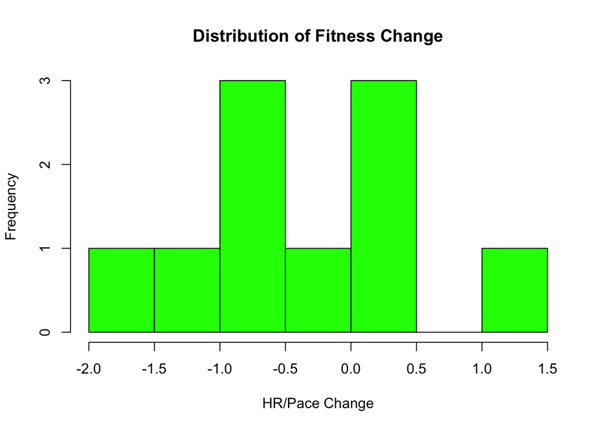

```r
# Adding fitness change to the data
# (heart rate per pace at peak - at end of season)
fitness <- fitness %>%
  mutate(
    HR_Pace_Peak = HR_Peak / Pace_Peak,
    HR_Pace_End = HR_End / Pace_End,
    Fitness_Change = HR_Pace_Peak - HR_Pace_End
  )

# creating histogram of fitness change
# (lower values = more improvement)
hist(fitness$Fitness_Change,
     main = "Distribution of Fitness Change",
     xlab = "HR/Pace Change",
     col = "green")
```

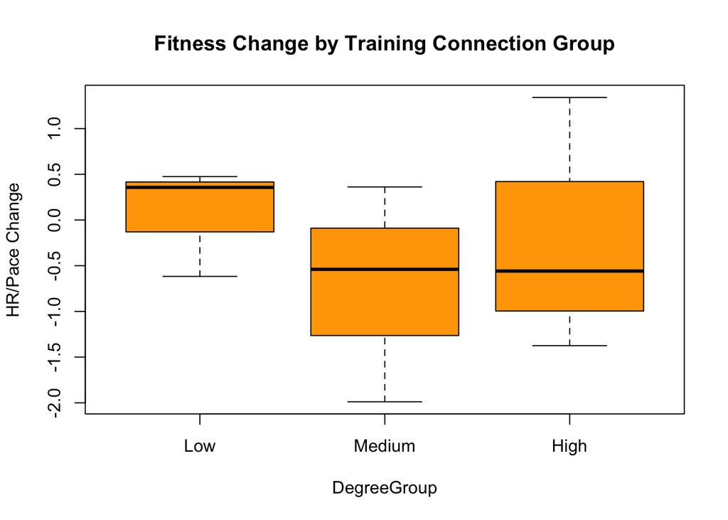

```r
# Grouping athletes by how many teammates they trained with
# Low = 0–3 connections, Medium = 4–6, High = 7–10
fitness$DegreeGroup <- cut(fitness$Degree,
                           breaks = c(0, 3, 6, 10),
                           labels = c("Low", "Medium", "High"))

# Making a boxplot to compare fitness change across those 3 groups
boxplot(Fitness_Change ~ DegreeGroup, data = fitness,
        main = "Fitness Change by Training Connection Group",
        ylab = "HR/Pace Change",
        col = "orange")  # makes the plot ornage
```

This boxplot shows how fitness change compares across athletes with low, medium, and high training connection groups. The medium and high groups had a wider range, meaning some athletes improved a lot while others didn’t. The low group had more consistent results, but their fitness change was mostly positive, which actually means they got slightly worse. So being more connected didn’t guarantee better results, but it came with more variability.

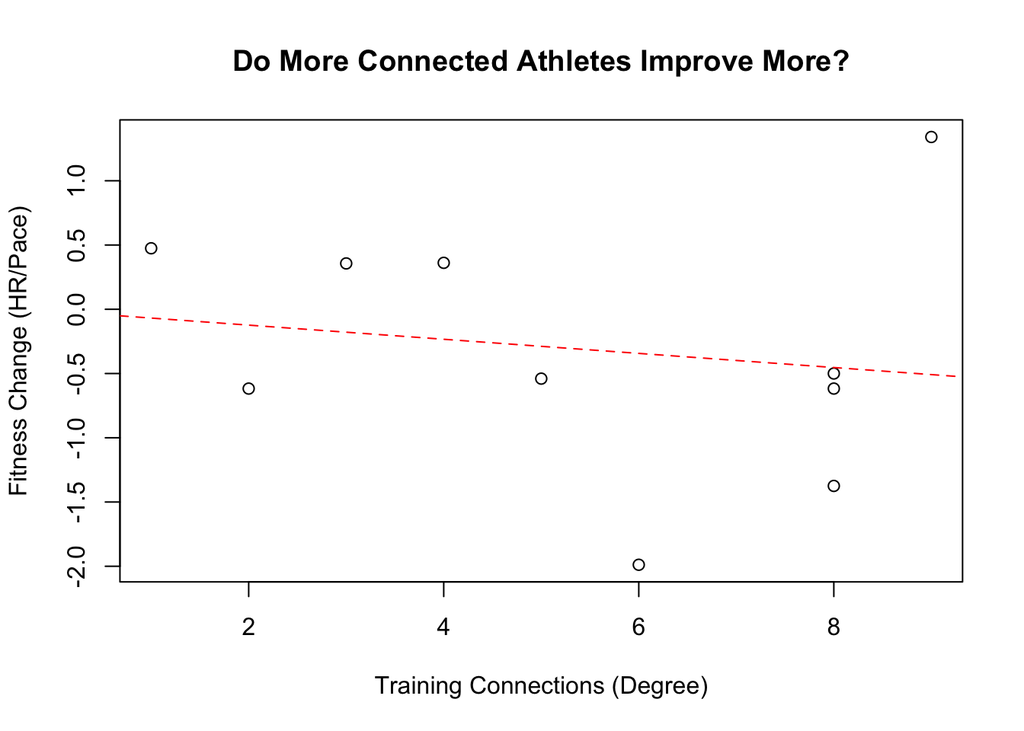

```r
#Network Centrality
# Calculating degree (number of connections)
fitness$Degree <- degree(g)

# Scatterplot: Degree vs Fitness Improvement
plot(fitness$Degree, fitness$Fitness_Change,
     main = "Do More Connected Athletes Improve More?",
     xlab = "Training Connections (Degree)",
     ylab = "Fitness Change (HR/Pace)")
abline(lm(Fitness_Change ~ Degree, data = fitness), col = "red", lty = 2)
```

```r
cor.test(fitness$Degree, fitness$Fitness_Change)
```

```
##
##  Pearson's product-moment correlation
##
## data:  fitness$Degree and fitness$Fitness_Change
## t = -0.46089, df = 8, p-value = 0.6571
## alternative hypothesis: true correlation is not equal to 0
## 95 percent confidence interval:
##  -0.7177724  0.5216170
## sample estimates:
##        cor
## -0.1608295
```

I ran a correlation test to see if there was a relationship between how connected someone was and how much their fitness changed. The result was a very weak negative correlation (r = -0.16), meaning there’s almost no relationship between training connections and improvement. The p-value was 0.66, which is way above 0.05, so the result isn’t statistically significant — this means we can’t say there’s a real connection between the two in this sample.

```r
#simple regression
model <- lm(Fitness_Change ~ Degree, data = fitness)
summary(model)
```

```
##
## Call:
## lm(formula = Fitness_Change ~ Degree, data = fitness)
##
## Residuals:
##     Min      1Q  Median      3Q     Max
## -1.6450 -0.4333 -0.1052  0.5411  1.8491
##
## Coefficients:
##             Estimate Std. Error t value Pr(>|t|)
## (Intercept) -0.01345    0.71985  -0.019    0.986
## Degree      -0.05499    0.11931  -0.461    0.657
##
## Residual standard error: 1.015 on 8 degrees of freedom
## Multiple R-squared:  0.02587,    Adjusted R-squared:  -0.0959
## F-statistic: 0.2124 on 1 and 8 DF,  p-value: 0.6571
```

I also ran a simple linear regression to see if training connections (Degree) could predict changes in fitness. The results showed a small negative slope (Estimate = -0.055), meaning that for each extra training connection, fitness change slightly decreased — but the effect was super weak. The p-value was 0.66, which means the result isn’t statistically significant, and the R-squared value was only 0.03. So overall, this model doesn’t explain much — how connected someone was didn’t really predict whether they improved.

```r
# 5-number summary for fitness change
summary(fitness$Fitness_Change)
```

```
##    Min. 1st Qu.  Median    Mean 3rd Qu.    Max.
## -1.9884 -0.6173 -0.5198 -0.3104  0.3602  1.3407
```